# Chapter 3 Working with Strings

# 是格式修饰符，与 g 配合使用时，会强制为整数添加小数点（即使没有小数部分）

```python
"{:b}".format(42)
```

```
'101010'
```

```python
"{:#b}".format(42)
```

```
'0b101010'
```

最后一个组成部分是井号（#）选项，它被放置在符号和宽度（如果存在的话）之间。这会触发一种替代的转换形式，其细节因类型而异。例如，对于二进制、八进制和十六进制转换，会添加一个前缀。

```python
# Print a formatted price list with a given width
width=int(input('Please enter width: '))
price_width=10
item_width=width - price_width
header_fmt='{{:{}}}{{:>{}}}'.format(item_width,price_width)
# 这行代码是在 Python 中创建一个格式化字符串模板，用于对齐显示内容（通常是项目名称和价格之类的成对信息）。
# 解析如下：
# 外层的{{:{}}}{{:>{}}}是格式化字符串的模板，其中：
# {{:{}}} 会被格式化为左对齐的占位符
# {{:>{}}} 会被格式化为右对齐的占位符
# 双大括号{{和}}是为了在最终字符串中保留单个大括号{和}
# 通过.format(item_width, price_width)进行填充后：
# 第一个占位符会变成{:<item_width}（左对齐，宽度为 item_width）
# 第二个占位符会变成{:>price_width}（右对齐，宽度为 price_width）
# “header_fmt” 通常是 “header format”（头部格式）的缩写
fmt='{{:{}}}{{:>{}.2f}}'.format(item_width,price_width)
print('='*width)
print(header_fmt.format('Item', 'Price'))
print('-'*width)
print(fmt.format('Apples',0.4))
print(fmt.format('Pears',0.5))
print(fmt.format('Cantaloupes',1.92))
print(fmt.format('Prunes(2 lbs.)',12))
print('='*width)
```

```
===================================
Item                          Price
-----------------------------------
Apples                         0.40
Pears                          0.50
Cantaloupes                    1.92
Prunes(2 lbs.)                12.00
===================================
```

## String Methods

但字符串模块并未过时。尽管字符串方法已经完全取代了字符串模块，但该模块仍然包含一些字符串方法所不具备的常量和函数。以下是 string2 中一些有用的常量：

・string.digits：包含数字 0–9 的字符串

・string.ascii_letters：包含所有 ASCII 字母（大写和小写）的字符串

・string.ascii_lowercase：包含所有小写 ASCII 字母的字符串

・string.printable：包含所有可打印 ASCII 字符的字符串

・string.punctuation：包含所有 ASCII 标点字符的字符串

・string.ascii_uppercase：包含所有大写 ASCII 字母的字符串

尽管明确涉及 ASCII 字符，但这些值实际上是（未编码的）Unicode 字符串。

### center

```python
"The Middle by Jimmy Eat World".center(39)
```

```
'     The Middle by Jimmy Eat World     '
```

```python
"The Middle by Jimmy Eat World".center(39,"*")
```

```
'*****The Middle by Jimmy Eat World*****'
```

### find

```python
'With a moo-moo here, and a moo-moo there'.find('moo')
```

```
7
```

find 方法用于在一个较长的字符串中查找子字符串。它返回子字符串被找到的最左侧索引。如果未找到子字符串，则返回–1。

```python
title="Monty Python's Flying Circus"
title.find("Monty")
```

```
0
```

```python
title.find('Python')
```

```
6
```

```python
title.find('Flying')
```

```
15
```

```python
title.find('Zirquss')
```

```
-1
```

```python
subject='$$$ Get rich now!!! $$$'
subject.find('$$$')
```

```
0
```

```python
subject.find('$$$', 1) # Only supplying the start
```

```
20
```

第二个参数1指定了搜索的起始位置（字符串索引从 0 开始，所以 1 表示从第二个字符开始）

```python
subject.find('!!!')
```

```
16
```

```python
subject.find('!!!', 0, 16) # Supplying start and end
```

```
-1
```

### join

```python
seq=[1,2,3,4,5]
sep= '+'
sep.join(seq) # Trying to join a list of numbers
```

```
---------------------------------------------------------------------------
TypeError                                 Traceback (most recent call last)
Cell In[97], line 3
      1 seq=[1,2,3,4,5]
      2 sep= '+'
----> 3 sep.join(seq)

TypeError: sequence item 0: expected str instance, int found
```

sep 是作为分隔符的字符串

```python
seq=['1','2','3','4','5']
sep.join(seq) # Joining a list of strings
```

```
'1+2+3+4+5'
```

```python
dirs='','usr','bin','env'
'/'.join(dirs)
```

```
'/usr/bin/env'
```

然后调用'/'.join(dirs)，意思是用'/'作为连接符，将元组dirs中的所有字符串元素连接起来

```python
print('C:' +'\\'.join(dirs))
```

```
C:\usr\bin\env
```

join() 是 Python 字符串的方法，作用是将一个可迭代对象（如列表 dirs）中的所有元素，用调用它的字符串（此处是 '\'）连接成一个新字符串。 '\' 是转义字符，表示实际要使用的单个反斜杠 \（因为在 Python 字符串中，\ 本身需要转义才能表示自身，避免被识别为特殊符号，如 \n 代表换行）。

### lower

```python
'Trondheim Hammer Dance'.lower()
```

```
'trondheim hammer dance'
```

```python
if 'Gumby' in ['gumby','smith','jones']: print('Found it!')
```

```python
name='Gumby'
names=['gumby','smith','jones']
if name.lower() in names:print('Found it!')
```

```
Found it!
```

ower 的一个相关方法是 title 方法（参见附录 B），该方法会将字符串转换为首字母大写格式 —— 也就是说，所有单词都以大写字母开头，其他所有字符都为小写。不过，单词边界的定义方式可能会导致一些不自然的结果。

```python
"that's all folks".title()
```

```
"That'S All Folks"
```

```python
import string
string.capwords("that's all, folks")
```

```
"That's All, Folks"
```

### replace

```python
'This is a test'.replace('is','eez')
```

```
'Theez eez a test'
```

### spilt

```python
'1+2+3+4+5'.split('+')
```

```
['1', '2', '3', '4', '5']
```

```python
'/usr/bin/env'.split('/')
```

```
['', 'usr', 'bin', 'env']
```

```python
'Using the default'.split()
```

```
['Using', 'the', 'default']
```

### strip

```python
'    internal whitespace is kept    '.strip()
```

```
'internal whitespace is kept'
```

```python
names = ['gumby', 'smith', 'jones']
name = 'gumby '
if name in names: print('Found it!')
# strip 方法会返回一个字符串，其中左右两侧（但不是内部）的空白字符已被去除（删除）
```

```python
 if name.strip() in names: print('Found it!')
# name.strip()：对变量name进行处理，strip()方法会移除字符串前后的空白字符（如空格、换行符等）
```

```
Found it!
```

```python
'*** SPAM * for * everyone!!! ***'.strip(' *!')
```

```
'SPAM * for * everyone'
```

与 replace 类似，translate 也会替换字符串的部分内容，但和 replace 不同的是，translate 仅适用于单个字符。它的优势在于能够同时执行多项替换，而且比 replace 更高效。

```python
table = str.maketrans('cs', 'kz')
```

```python
 table
```

```
{99: 107, 115: 122}
```

```python
'this is an incredible test'.translate(table)
```

[output not shown]

```python
table = str.maketrans('cs', 'kz', ' ')
'this is an incredible test'.translate(table)
```

```
'thizizaninkredibletezt'
```

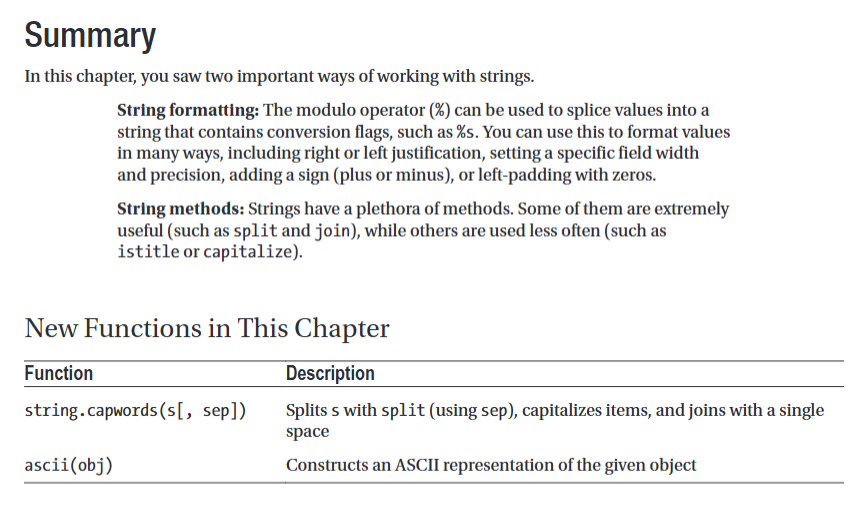